# There And Back Again

Differences When Transforming

R.W. Oldford and Zehao Xu

2024-03-28

# Some data

Consider the following artificially generated dataset:

```r
data <- data.frame(A = c(19, 19, 25, 62, 34,
                         58, 62, 40, 24, 60,
                         70, 40, 40, 34, 26),
                   B = c(68, 63, 63, 13, 55,
                         78, 14, 14, NA, 28,
                         NA, 55, 57, 40, 78) )
```

# `ggplot` to `loon` transformation

## the `ggplot` and its states

Begin with a `ggplot` defined using the interactive grammar extension:

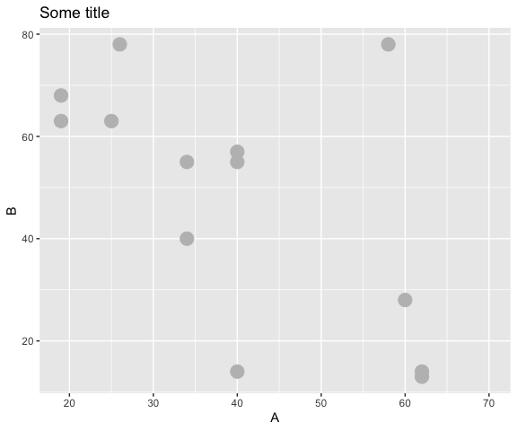

```r
ggp <- ggplot(data,
               mapping = aes(x = A, y = B)) +
  ggtitle("Some title") +
  geom_point(color = "grey", size = 5) +
  linking(linkingGroup = "my plots")
plot(ggp)
```

Information on the `ggplot` corresponding to `loon` states is had using `ggplot_build()`

```r
# get the ggplot data corresponding to loon "states"
ggp_states <- ggplot_build(ggp)$data[[1]]
ggp_states
```

```
#>     x  y PANEL group shape colour size fill alpha stroke
#> 1  19 68     1    -1    19   grey    5   NA    NA    0.5
#> 2  19 63     1    -1    19   grey    5   NA    NA    0.5
#> 3  25 63     1    -1    19   grey    5   NA    NA    0.5
#> 4  62 13     1    -1    19   grey    5   NA    NA    0.5
#> 5  34 55     1    -1    19   grey    5   NA    NA    0.5
#> 6  58 78     1    -1    19   grey    5   NA    NA    0.5
#> 7  62 14     1    -1    19   grey    5   NA    NA    0.5
#> 8  40 14     1    -1    19   grey    5   NA    NA    0.5
#> 9  24 NA     1    -1    19   grey    5   NA    NA    0.5
#> 10 60 28     1    -1    19   grey    5   NA    NA    0.5
#> 11 70 NA     1    -1    19   grey    5   NA    NA    0.5
#> 12 40 55     1    -1    19   grey    5   NA    NA    0.5
#> 13 40 57     1    -1    19   grey    5   NA    NA    0.5
#> 14 34 40     1    -1    19   grey    5   NA    NA    0.5
#> 15 26 78     1    -1    19   grey    5   NA    NA    0.5
```

Note that some of the `x` and `y` values are `NA`, representing missing values.

## the `loon` plot and its states

Now construct the `loon` plot from this `ggplot`:

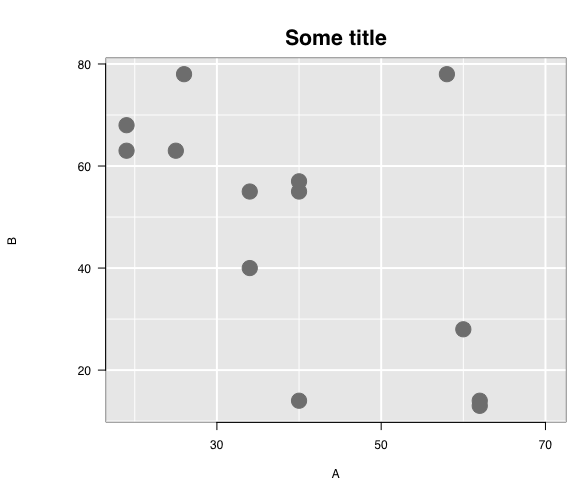

```r
lp <- loon.ggplot(ggp)
plot(lp)
```

The `loon` plot looks slightly different:

- title in a different position,
- the relative sizes of the margins and drawing areas,
- axis tic marks and labels,
- font sizes and styles, and
- points are a slightly darker grey in the `loon` plot.

Plots in `loon` have more constrained layouts than those in `ggplot2`, since focus is primarily on interactive as opposed to publication quality graphics.  
Some differences (e.g., colour) are also because `loon` is based on `Tcl` for drawing primitives.

Plot states in `loon` are accessible using `[]` and the name of the state. Values are assigned in the same way. Names of interactively changeable states in `loon` are

```r
names(lp)
```

```
#>  [1] "glyph"            "itemLabel"        "showItemLabels"   "linkingGroup"
#>  [5] "linkingKey"       "zoomX"            "zoomY"            "panX"
#>  [9] "panY"             "deltaX"           "deltaY"           "xlabel"
#> [13] "ylabel"           "title"            "showLabels"       "showScales"
#> [17] "swapAxes"         "showGuides"       "background"       "foreground"
#> [21] "guidesBackground" "guidelines"       "minimumMargins"   "labelMargins"
#> [25] "scalesMargins"    "x"                "y"                "xTemp"
#> [29] "yTemp"            "color"            "selected"         "active"
#> [33] "size"             "tag"              "useLoonInspector" "selectBy"
#> [37] "selectionLogic"
```

```r
# and accessed with [] as in
lp["title"]
```

```
#> [1] "Some title"
```

(See also `?l_info_states`.)

Some, like `x`, `y`, and `color`, are *n-dimensional states* whose values correspond to those on individual observations. These may be changed using the `[] <-` notation as well.

Because `loon` plots exclude observations missing values in any its n-dimensional states, the `loon` plot will have fewer observations than the corresponding `ggplot`, even though the same number of points may be plotted. The actual number of observations in the `loon` plot is

```r
lp["n"]
```

```
#> [1] 13
```

which is less than the number of observations recorded in the `ggplot` structure (namely `nrow(ggp_states) =` 15).

## changing from ggplot to loon

Differences between `ggplot` structure and `loon` plot structure (and how these affect the visualizations) is worth exploring in a little more detail. A better understanding will be helpful when transforming back and forth between the two.

### shape to glyph

In `R` the point symbol plotted is associated with a numerical code `pch`. In `loon` the point symbol is a glyph, identified by a string.

```r
ggp_states$shape
```

```
#>  [1] 19 19 19 19 19 19 19 19 19 19 19 19 19 19 19
```

```r
lp["glyph"]
```

```
#>  [1] "circle" "circle" "circle" "circle" "circle" "circle" "circle" "circle"
#>  [9] "circle" "circle" "circle" "circle" "circle"
```

As with other plot “states”, there is not always a `glyph` in `loon` that matches a `pch` in `R`. Values of `pch` with no counterpart in `loon` will map to the default `glyph` in `loon`.

### point size

Size is another plot state that differs between `ggplot` and `loon`.

```r
ggp_states$size
```

```
#>  [1] 5 5 5 5 5 5 5 5 5 5 5 5 5 5 5
```

```r
lp["size"]
```

```
#>  [1] 26.78116 26.78116 26.78116 26.78116 26.78116 26.78116 26.78116 26.78116
#>  [9] 26.78116 26.78116 26.78116 26.78116 26.78116
```

### colours

Comparing the plots, the points are slightly different `"grey"` in one plot than in the other.

This is because the two plots have different values stored as their colour state:

```r
ggp_states$colour
```

```
#>  [1] "grey" "grey" "grey" "grey" "grey" "grey" "grey" "grey" "grey" "grey"
#> [11] "grey" "grey" "grey" "grey" "grey"
```

```r
lp["color"]
```

```
#>  [1] "#808080808080" "#808080808080" "#808080808080" "#808080808080"
#>  [5] "#808080808080" "#808080808080" "#808080808080" "#808080808080"
#>  [9] "#808080808080" "#808080808080" "#808080808080" "#808080808080"
#> [13] "#808080808080"
```

First, there is a slight difference between what `R` regards as `"grey"` and what `Tcl` (used by `loon`) regards as `"grey"`. Several other **named** colours in `R` also differ slightly from those in `Tcl` and hence in `loon`. `R` colours whose name **is the same** as that in `Tcl` **but whose colour is different** are **only** the following:

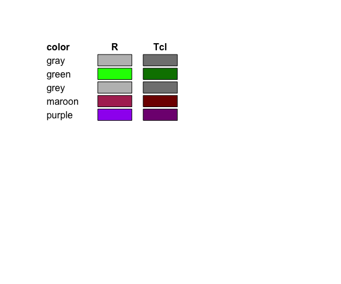

(See `?tkcolors` in `loon` for more information.)

Second, `loon` plot colour values are strings of **twelve** hexadecimal digits, as in `tk` (e.g., see `?tkcolors`); in contrast, the `ggplot` are either strings corresponding to the named `R` colours (see `?grDevices::colors` in `R`) or to **six** hexadecimal digits (two for each of the red, green, and blue components).

Twelve hex digit colours are turned into six hex digits using the `loon` function `hex12to6()`. To convert the `R` named colours to six hex digits, the following function can be used.

```r
tohex <- function(x) {
    sapply(x, function(xi) {
        crgb <- as.vector(col2rgb(xi))
        rgb(crgb[1], crgb[2], crgb[3], maxColorValue = 255)
    })}
```

So, comparing the two `"grey"` colours, the `ggplot` has the `R` hex colour `tohex("grey") =` #BEBEBE and the `loon` plot has `Tcl` hex colour (converted to hex 6) `hex12tohex6(lp["color"][1]) =` #808080, which are clearly different RGB values.

## effect of missing data

The `loon` plot does not include the missing data

```r
nrow(ggp_states) == lp["n"]
```

```
#> [1] FALSE
```

```r
# Compare
ggp_states$y
```

```
#>  [1] 68 63 63 13 55 78 14 14 NA 28 NA 55 57 40 78
```

```r
lp["y"]
```

```
#>  [1] 68 63 63 13 55 78 14 14 28 55 57 40 78
```

Note that, absent the missing `NA`s, the **order** of the points is identical.

### on linking keys

Default linking keys in `loon` are from `"0"` to `"n-1"` where `"n"` is the number of rows in the original data set.  
Here `nrow(data) =` 15. Note that this `"n"` is not the number of points actually plotted because `loon` drops the missing data, unlike `ggplot`.

The linking keys reflect this missingness:

```r
lp["linkingKey"]
```

```
#>  [1] "0"  "1"  "2"  "3"  "4"  "5"  "6"  "7"  "9"  "11" "12" "13" "14"
```

which is missing `"8"` and `"10"`. Note also that `lp["n"] =` 13 is the number of points plotted in the `loon` plot.

Some care needs to be taken when dealing with linking, especially when there is missing data.

### for more information

See the vignette [Linking](https://great-northern-diver.github.io/loon.ggplot/articles/linking.html) and the `loon` vignette [Logical Queries](https://great-northern-diver.github.io/loon/articles/logicalQueries.html) for more information.

# `loon` to `ggplot` transformation

A `ggplot` from the `loon` plot will not have access to the original information.

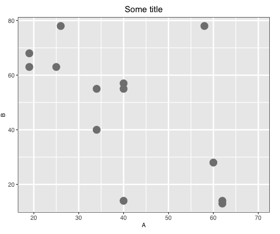

```r
ggp_lp_1 <- loon.ggplot(lp)
ggp_lp_1
```

Note that, though a `ggplot`, the position of the title is now centred. This is because the objective of the transformation is to create a `ggplot` that looks as much like the original `loon` plot as possible.

## the `ggplot` states

To try to reflect the look of the `loon` plot, the states of the `ggplot` are **different** from those of the original `ggplot` `ggp`.

```r
ggp_lp_1_states <- ggplot_build(ggp_lp_1)$data[[1]]
ggp_lp_1_states
```

```
#>     colour size  x  y PANEL group shape fill alpha stroke
#> 1  #808080    5 19 68     1     1    19   NA    NA    0.5
#> 2  #808080    5 19 63     1     1    19   NA    NA    0.5
#> 3  #808080    5 25 63     1     1    19   NA    NA    0.5
#> 4  #808080    5 62 13     1     1    19   NA    NA    0.5
#> 5  #808080    5 34 55     1     1    19   NA    NA    0.5
#> 6  #808080    5 58 78     1     1    19   NA    NA    0.5
#> 7  #808080    5 62 14     1     1    19   NA    NA    0.5
#> 8  #808080    5 40 14     1     1    19   NA    NA    0.5
#> 9  #808080    5 60 28     1     1    19   NA    NA    0.5
#> 10 #808080    5 40 55     1     1    19   NA    NA    0.5
#> 11 #808080    5 40 57     1     1    19   NA    NA    0.5
#> 12 #808080    5 34 40     1     1    19   NA    NA    0.5
#> 13 #808080    5 26 78     1     1    19   NA    NA    0.5
```

```r
lp_ggp_lp_1 <- loon.ggplot(ggp_lp_1)
```

## After interactive changes

Perform some interactive changes, including selecting some points

```r
selection <- lp["x"] > 50 &lp["y"] > 13
lp["selected"] <- selection
colorMeRed <- lp["x"] == 34
lp["color"][colorMeRed] <- "red"
```

### linking keys after `loon.ggplot()`

Linking problems can arise whenever a `ggplot` constructed from a `loon` plot is then made interactive again.

Suppose a `loon` plot, like `lp`, is turned into a `ggplot` (typically, after some interactive changes) via `loon.ggplot()`, and the resulting new `ggplot` is then itself turned into another interactive plot. The new interactive plot will not necessarily share the same linking information as the original.

This is because the second interactive plot will have the default values of `linkingGroup`, `linkingKey` and linked display states; these values are lost in the transfer from the first interactive plot to the `ggplot`. That is,

- the *linking group* is not automatically carried over to the second interactive plot
- the *linked states* are not automatically carried over to the second interactive plot
- the default *linking keys* in the second interactive plot are `"0"`, …, `"n-1"` where `n` is the number of observations that were displayed in the first plot.

  So, provided the first interactive plot has the default linking keys (and was built with complete data; i.e., no data was missing at creation), then the linking keys will match.

An **important special case** is when some observations were **selected** in the first interactive plot at the time the `ggplot` is created. In this case, the **linking keys will typically not match.**

For example,

```r
# Get a ggplot from the loon plot
ggp_lp <- loon.ggplot(lp)
```

The interactive `lp` and the new `ggplot` `ggp_lp` appear as follows.

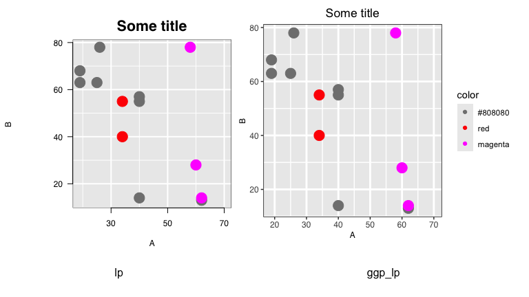

The left plot, `lp`, is an interactive `loon` plot and the magenta points are selected. The right plot, `ggp_lp`, is a static `ggplot` which has no `selected` state and the magenta points are simply points having that colour (and appear as that in the `ggplot` legend).

In an interactive plot, selected points are visually emphasized in two ways:

- their colour is changed to the highlight colour (here magenta), and
- the corresponding part of the display (here the points) are drawn **on top** of the rest of the display.

When transferring that to a `ggplot`, the selected points appear with the highlight colour **and** the **data order is changed** in the `ggplot` so that they appear on top of all other points in the display. If, instead, the argument `selectedOnTop = FALSE` is given to `loon.ggplot()` call, then the order of points will not be changed in the `ggplot`. This is **strongly recommended** whenever the `ggplot` will later be turned into an interactive plot; this will allow the linking to match more easily with the original interactive plot.

To see the effect of this (and of missing values) on linking, suppose an interactive plot is created from the `ggplot` `ggp_lp`:

```r
# The loon plot from the resulting ggplot
lp_ggp_lp <- loon.ggplot(ggp_lp)
```

Compare the linking keys of this plot with the original:

```r
# The original loon plot has linking keys
lp["linkingKey"]
```

```
#>  [1] "0"  "1"  "2"  "3"  "4"  "5"  "6"  "7"  "9"  "11" "12" "13" "14"
```

```r
# And the loon plot from the derived ggplot
lp_ggp_lp["linkingKey"]
```

```
#>  [1] "0"  "1"  "2"  "3"  "4"  "5"  "6"  "7"  "8"  "9"  "10" "11" "12"
```

The difference is that `lp` was created with data missing values corresponding to the missing linking keys `"8"` and `"10"`. This information was not available on the `ggplot` `ggp_lp` so that the new `loon` plot would be created with the default values `"0"` to `"12"`. The result is that some points will be wrongly linked between `lp` and `lp_ggp_lp`.

The selected points in `lp` (highlighted magenta) will cause reordering in `ggp_lp` and hence in `lp_ggp_lp`. This too will cause problems in linking and other states of the new `lp_ggp_lp`. For example, the two point orders can be seen in the respective values of their `"x"`:

```r
# The original point order
lp["x"]
```

```
#>  [1] 19 19 25 62 34 58 62 40 60 40 40 34 26
```

```r
# The new plot's order
lp_ggp_lp["x"]
```

```
#>  [1] 19 19 25 62 34 40 40 40 34 26 58 62 60
```

This makes problems for matching the correct observations.

Other states are also changed because of the transition from `loon` plot to `ggplot` to `loon` plot. In particular, the `"color"` and `"selected"` states will not match.

```r
# Original selected
lp["selected"]
```

```
#>  [1] FALSE FALSE FALSE FALSE FALSE  TRUE  TRUE FALSE  TRUE FALSE FALSE FALSE
#> [13] FALSE
```

```r
# the new plot has nothing selected
lp_ggp_lp["selected"]
```

```
#>  [1] FALSE FALSE FALSE FALSE FALSE FALSE FALSE FALSE FALSE FALSE FALSE FALSE
#> [13] FALSE
```

```r
# Original selected
lp["color"]
```

```
#>  [1] "#808080808080" "#808080808080" "#808080808080" "#808080808080"
#>  [5] "#FFFF00000000" "#808080808080" "#808080808080" "#808080808080"
#>  [9] "#808080808080" "#808080808080" "#808080808080" "#FFFF00000000"
#> [13] "#808080808080"
```

```r
# the new plot has nothing selected
lp_ggp_lp["color"]
```

```
#>  [1] "#808080808080" "#808080808080" "#808080808080" "#808080808080"
#>  [5] "#FFFF00000000" "#808080808080" "#808080808080" "#808080808080"
#>  [9] "#FFFF00000000" "#808080808080" "#FFFF0000FFFF" "#FFFF0000FFFF"
#> [13] "#FFFF0000FFFF"
```

When observations are also **highlighted** in the original `loon` plot, as in `lp`, a little more care needs to be taken with respect to the linking keys. The problem is that in constructing the `ggplot`, the data has to be reordered to ensure that the selected highlighted points appear on top of the other points in the `ggplot`.

Care needs to be taken to manage the linking keys when moving from the static `ggplot` to the interactive `loon` plot. This information can be added when the interactive plot is created, as arguments to `loon.ggplot()` as follows.

```r
# Add the linking information when creating the interactive plot
lp_ggp_l1_lk <- loon.ggplot(ggp_lp,
                            linkingKey =lp["linkingKey"],
                            linkingGroup = "NA example")
# Now compare
lp_ggp_l1_lk["linkingKey"]
```

```
#>  [1] "0"  "1"  "2"  "3"  "4"  "5"  "6"  "7"  "9"  "11" "12" "13" "14"
```

```r
# to the original loon plot
lp["linkingKey"]
```

```
#>  [1] "0"  "1"  "2"  "3"  "4"  "5"  "6"  "7"  "9"  "11" "12" "13" "14"
```

Alternatively, the grammar could have been used as in

```r
# Add the linking information when creating the interactive plot
lp_ggp_l1_ggk <- loon.ggplot(ggp_lp +
                               linking(linkingGroup = "NA example",
                                       linkingKey =lp["linkingKey"]))
# Again compare
lp_ggp_l1_ggk["linkingKey"]
```

```
#>  [1] "0"  "1"  "2"  "3"  "4"  "5"  "6"  "7"  "9"  "11" "12" "13" "14"
```

```r
# to the original loon plot
lp["linkingKey"]
```

```
#>  [1] "0"  "1"  "2"  "3"  "4"  "5"  "6"  "7"  "9"  "11" "12" "13" "14"
```

Of course, all this depends on the user knowing where to find the correct linking information.

Comparing the three different interactive plots shows how information can be lost, as well as how it can be maintained, when translating from interactive to static `ggplot` back to an interactive `loon` plot.